# MPDW PERTEMUAN 5

Zafira Ilma Fitri

2023-10-02

```r
library(ggplot2)
library(tsibble)
library(tseries)
library(MASS)
```

```r
library(readxl)
data <- read_excel("C:/Users/Zifferentpg/OneDrive/Documents/mpdw.xlsx")
summary(data)
```

```
##       date            value
##  Min.   :  1.00   Min.   :308833
##  1st Qu.: 30.75   1st Qu.:314163
##  Median : 60.50   Median :319837
##  Mean   : 60.50   Mean   :319697
##  3rd Qu.: 90.25   3rd Qu.:325231
##  Max.   :120.00   Max.   :330309
```

```r
value <- ts(data$value)
```

## Stasioner dalam Rataan dan Ragam

Pada dasarnya, pembangkitan data ARIMA akan menghasilkan data yang stasioner dalam rataan dan ragam karena akan mengikuti fungsi *default*-nya yang mengikuti pembangkitan bilangan acak normal dengan `mean=0` dan `ragam=1` .

### Plot *Time Series*

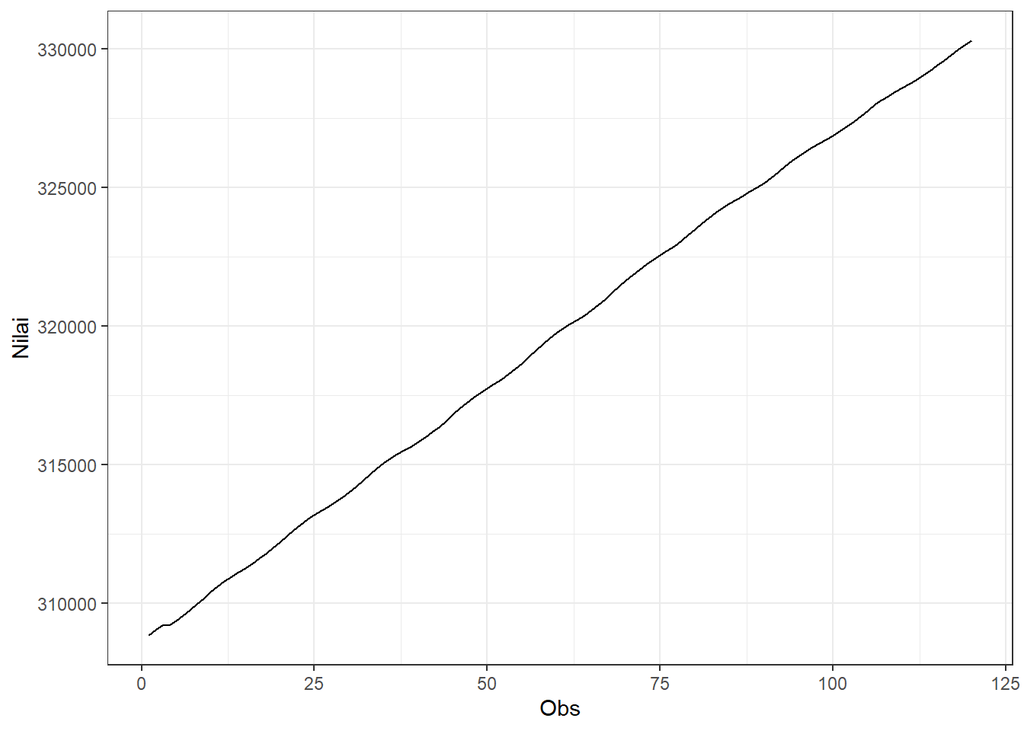

```r
plot_stas <- value |> as_tsibble() |>
  ggplot(aes(x = index, y = value)) + geom_line() + theme_bw() +
  xlab("Obs") + ylab("Nilai")
plot_stas
```

```r
mean(value)
```

```
## [1] 319696.9
```

Plot deret waktu di atas menunjukkan bahwa data tidak stasioner dalam rataan dan tidak stasioner dalam ragam. Dari plot deret waktu diatas dapat dilihat data cenderung membentuk pola trend

### Plot ACF

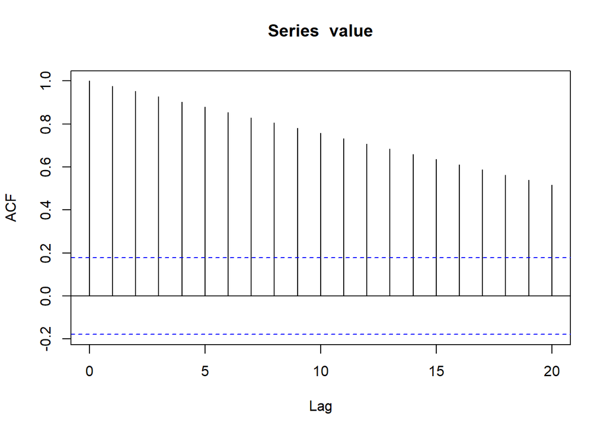

```r
acf(value)
```

### Uji ADF

```r
tseries::adf.test(value)
```

```
##
##  Augmented Dickey-Fuller Test
##
## data:  value
## Dickey-Fuller = 0.97349, Lag order = 4, p-value = 0.99
## alternative hypothesis: stationary
```

$H_0$ : Data tidak stasioner dalam rataan

$H_1$ : Data stasioner dalam rataan

Berdasarkan uji ADF tersebut, didapat *p-value* sebesar 0.99 yang lebih besar dari taraf nyata 5% sehingga tidak tolak $H_0$ dan menandakan bahwa data tidak stasioner dalam rataan. Hal ini sesuai dengan hasil eksplorasi menggunakan plot time series dan plot ACF.

### Plot Box-Cox

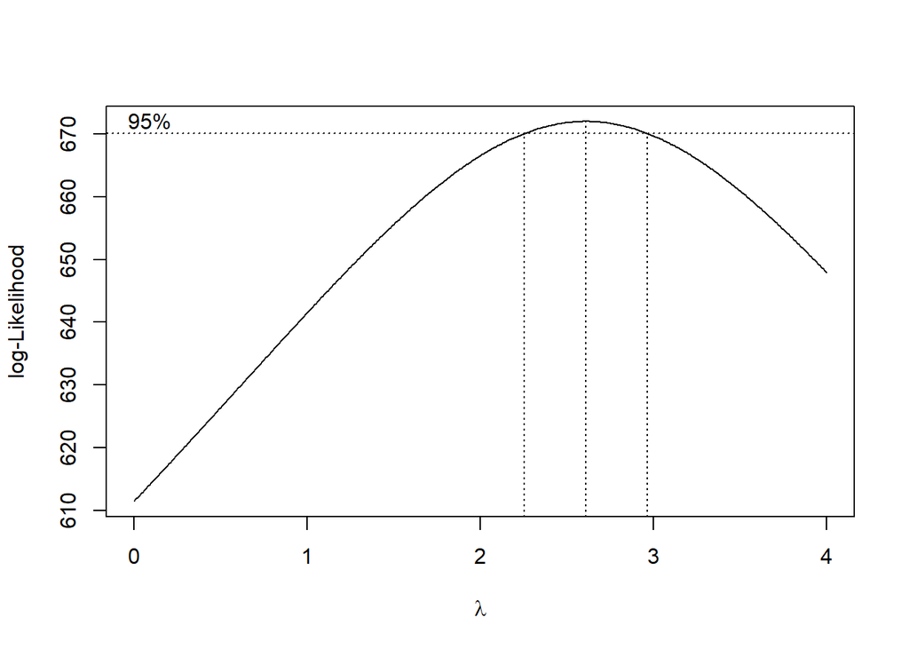

```r
index <- seq(1:120)
bc = boxcox(value~index, lambda = seq(0,4,by=0.01))
```

```r
#Nilai Rounded Lambda
lambda <- bc$x[which.max(bc$y)]
lambda
```

```
## [1] 2.61
```

```r
#SK
bc$x[bc$y > max(bc$y) - 1/2 * qchisq(.95,1)]
```

```
##  [1] 2.26 2.27 2.28 2.29 2.30 2.31 2.32 2.33 2.34 2.35 2.36 2.37 2.38 2.39 2.40
## [16] 2.41 2.42 2.43 2.44 2.45 2.46 2.47 2.48 2.49 2.50 2.51 2.52 2.53 2.54 2.55
## [31] 2.56 2.57 2.58 2.59 2.60 2.61 2.62 2.63 2.64 2.65 2.66 2.67 2.68 2.69 2.70
## [46] 2.71 2.72 2.73 2.74 2.75 2.76 2.77 2.78 2.79 2.80 2.81 2.82 2.83 2.84 2.85
## [61] 2.86 2.87 2.88 2.89 2.90 2.91 2.92 2.93 2.94 2.95 2.96
```

Gambar di atas menunjukkan nilai *rounded value* ($\lambda$) optimum sebesar **2,61** dan pada selang kepercayaan 95% nilai memiliki batas bawah **2,26** dan batas atas **2,96**. Selang tersebut tidak memuat nilai satu sehingga dapat dikatakan bahwa data tidak stasioner dalam ragam.

### Partisi Data

#### Bagian 1

```r
dt_stas1 <- value[1:60] |> ts()
mean(dt_stas1)
```

```
## [1] 314157.7
```

```r
var(dt_stas1)
```

```
## [1] 10421647
```

#### Plot Time Series

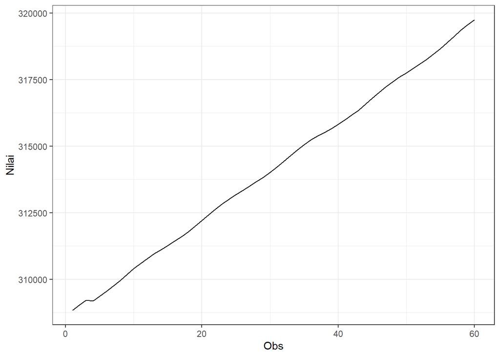

```r
dt_stas1 |> as_tsibble() |>
  ggplot(aes(x = index, y = value)) +
  geom_line() + theme_bw() +
  xlab("Obs") + ylab("Nilai")
```

Plot deret waktu di atas menunjukkan bahwa data tidak stasioner dalam rataan dan tidak stasioner dalam ragam. Dari plot deret waktu diatas dapat dilihat data cenderung membentuk pola trend

#### Plot ACF

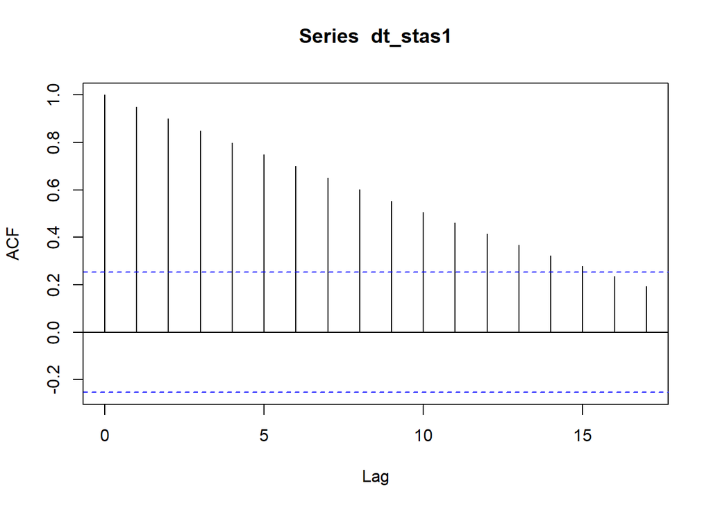

```r
acf(dt_stas1)
```

#### Uji ADF

```r
tseries::adf.test(dt_stas1)
```

```
##
##  Augmented Dickey-Fuller Test
##
## data:  dt_stas1
## Dickey-Fuller = -4.7394, Lag order = 3, p-value = 0.01
## alternative hypothesis: stationary
```

$H_0$ : Data tidak stasioner dalam rataan

$H_1$ : Data stasioner dalam rataan

Berdasarkan uji ADF tersebut, didapat *p-value* sebesar 0.01 yang lebih kecil dari taraf nyata 5% sehingga tolak $H_0$ dan menandakan bahwa data stasioner dalam rataan.

#### Plot Boxcox

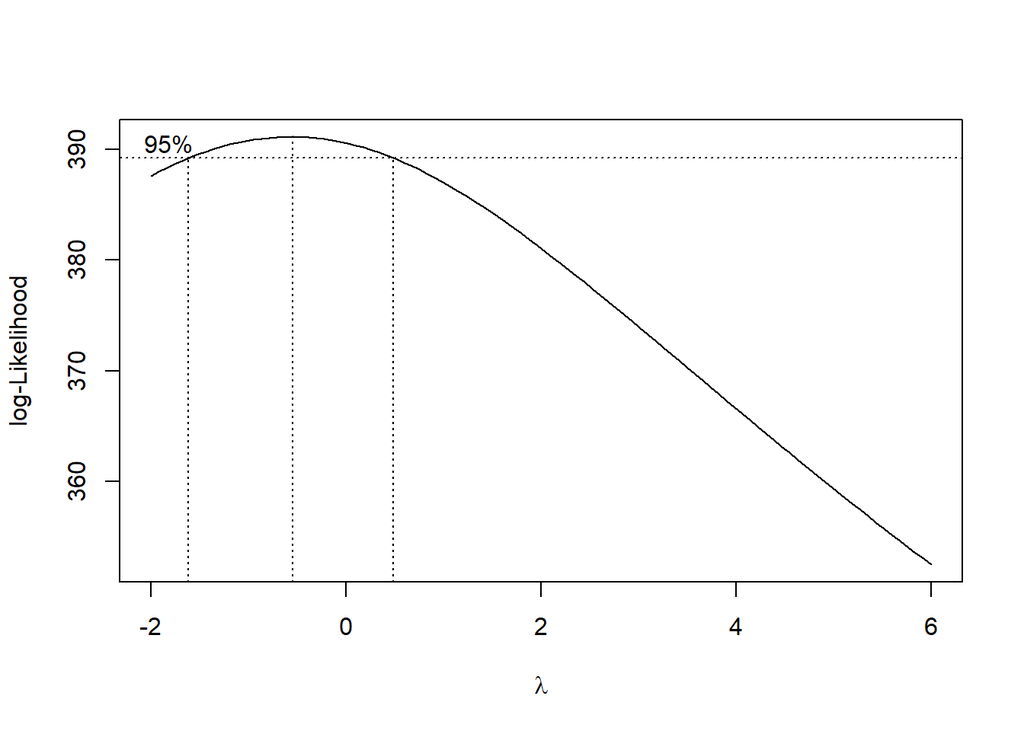

```r
index <- seq(1:60)
bc = boxcox(dt_stas1~index, lambda = seq(-2,6,by=1))
```

```r
#Nilai Rounded Lambda
lambda <- bc$x[which.max(bc$y)]
lambda
```

```
## [1] -0.5454545
```

```r
#SK
bc$x[bc$y > max(bc$y) - 1/2 * qchisq(.95,1)]
```

```
##  [1] -1.59595960 -1.51515152 -1.43434343 -1.35353535 -1.27272727 -1.19191919
##  [7] -1.11111111 -1.03030303 -0.94949495 -0.86868687 -0.78787879 -0.70707071
## [13] -0.62626263 -0.54545455 -0.46464646 -0.38383838 -0.30303030 -0.22222222
## [19] -0.14141414 -0.06060606  0.02020202  0.10101010  0.18181818  0.26262626
## [25]  0.34343434  0.42424242
```

Gambar di atas menunjukkan nilai *rounded value* ($\lambda$) optimum sebesar *-0.5454545 **dan pada selang kepercayaan 95% nilai memiliki batas bawah** -1.59595960 **dan batas atas** 0.42424242**. Selang tersebut tidak memuat nilai satu sehingga dapat dikatakan bahwa data tidak stasioner dalam ragam.

#### Bagian 2

```r
dt_stas2 <- value[61:120] |> ts()
mean(dt_stas2)
```

```
## [1] 325236
```

```r
var(dt_stas2)
```

```
## [1] 9349898
```

#### Plot Time Series

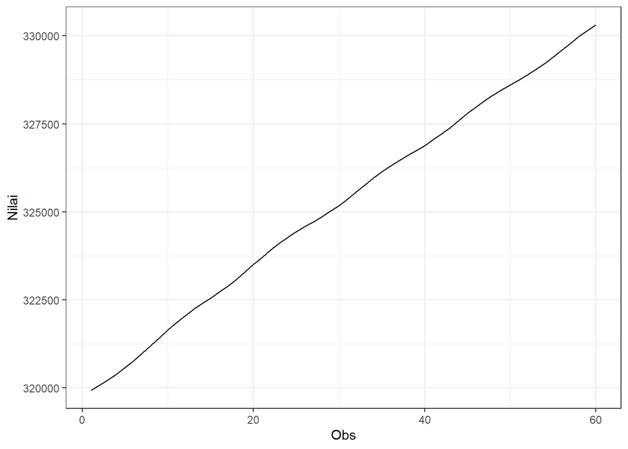

```r
dt_stas2 |> as_tsibble() |>
  ggplot(aes(x = index, y = value)) +
  geom_line() + theme_bw() +
  xlab("Obs") + ylab("Nilai")
```

Plot deret waktu di atas menunjukkan bahwa data tidak stasioner dalam rataan dan tidak stasioner dalam ragam. Dari plot deret waktu diatas dapat dilihat data cenderung membentuk pola trend

#### Plot ACF

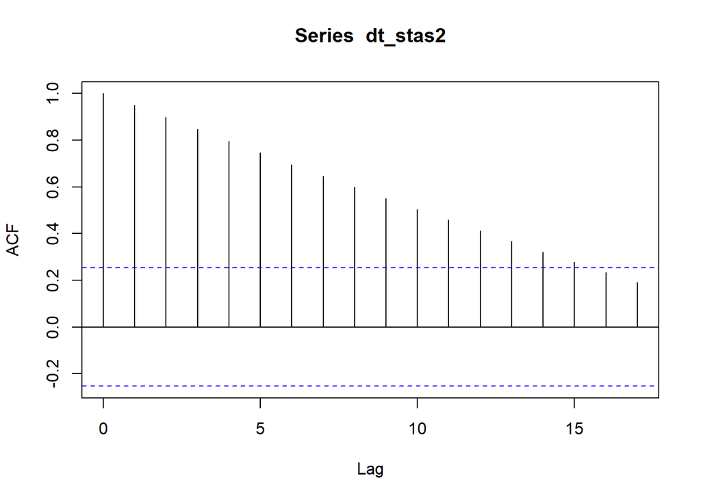

```r
acf(dt_stas2)
```

Berdasarkan plot ACF, terlihat bahwa plot ACF pada data tersebut cenderung tails off yaitu lag menurun secara lambat sehingga dapat disimpulkan bahwa data tidak stasioner dalam rataan

#### Uji ADF

```r
adf.test(dt_stas2)
```

```
##
##  Augmented Dickey-Fuller Test
##
## data:  dt_stas2
## Dickey-Fuller = -1.7751, Lag order = 3, p-value = 0.6657
## alternative hypothesis: stationary
```

$H_0$ : Data tidak stasioner dalam rataan

$H_1$ : Data stasioner dalam rataan

Berdasarkan uji ADF tersebut, didapat *p-value* sebesar 0.6657 yang lebih besar dari taraf nyata 5% sehingga tidak tolak $H_0$ dan menandakan bahwa data tidak stasioner dalam rataan. Hal ini sesuai dengan hasil eksplorasi menggunakan plot time series dan plot ACF.

#### Plot Boxcox

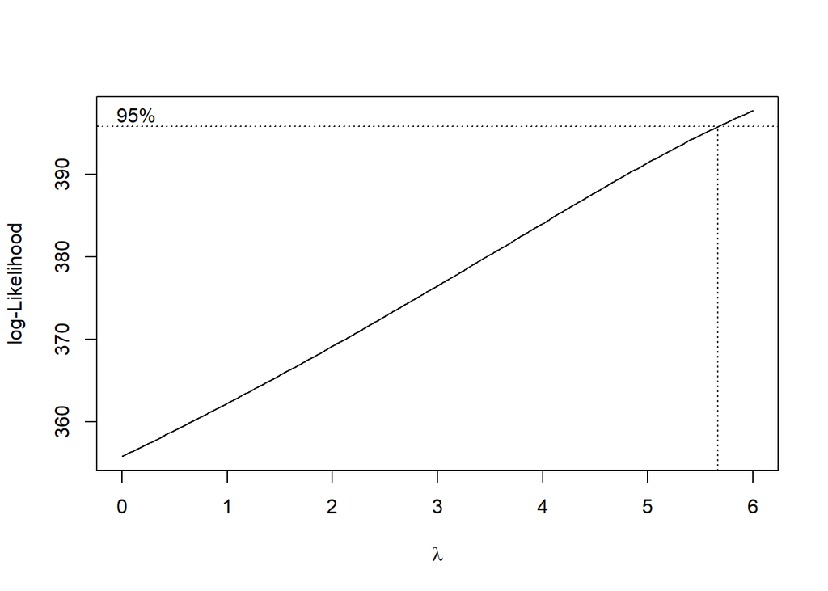

```r
index <- seq(61:120)
bc = boxcox(dt_stas2~index, lambda = seq(0,6,by=1))
```

```r
#Nilai Rounded Lambda
lambda <- bc$x[which.max(bc$y)]
lambda
```

```
## [1] 6
```

```r
#SK
bc$x[bc$y > max(bc$y) - 1/2 * qchisq(.95,1)]
```

```
## [1] 5.696970 5.757576 5.818182 5.878788 5.939394 6.000000
```

Gambar di atas menunjukkan nilai *rounded value* ($\lambda$) optimum sebesar **6** dan pada selang kepercayaan 95% nilai memiliki batas bawah **5.696970** dan batas atas **6.000000**. Selang tersebut tidak memuat nilai satu sehingga dapat dikatakan bahwa data tidak stasioner dalam ragam.